# ADHDCYCLE_daily

Last compiled on October 20, 2024

# 1 ———————————————————————————- SETUP

# 2 —- Setup —-

- Turns of Scientific Notation
- Saves ‘current_date’ as a string in YYYYMMDD format
- Sets the number of digits (3) to display in output
- Saves Current Date as a string in YYYYMMDD format
- Sets the ‘output_folder’ as path to the output folder for saving files

```r
knitr::opts_chunk$set(echo = TRUE) # Setting options for knitr to display R code in output
options(scipen = 999) # Turn off scientific notation
options(digits = 3) # Set number of digits to display

current_date <- format(Sys.Date(), "%Y%m%d")  # Produces date as YYYYMMDD

output_folder <- "/Users/taem-macbook-air/Library/CloudStorage/Box-Box/00 - CLEAR Lab (Locked Folders)/02 - Data Management, Analysis, and Papers/Studies_Projects/CYCLEADHD/03_analytic_projects/CYCADHD_PRIMARY/03_code_dataedits_output/"
```

# 3 —- Load Packages (no cache) —-

```r
# ---- Global Chunk Options and Settings ----

# Setting options for knitr to display R code in output
knitr::opts_chunk$set(echo = TRUE)

# Prevent scientific notation in outputs
options(scipen = 999)

# ---- Data Manipulation and Cleaning ----

# Core tidyverse libraries for data manipulation and visualization
library(dplyr)       # Data manipulation (part of tidyverse)
```

```r
library(tidyr)       # Data tidying (part of tidyverse)
library(tidyverse)   # Meta-package, includes dplyr, tidyr, ggplot2, and others
library(janitor)     # For cleaning data, e.g., renaming columns, removing empty rows
library(skimr)       # Summarize and inspect data quickly


# ---- Reading and Working with Files ----

# Libraries for reading various file formats
library(haven)       # For reading SPSS, Stata, and SAS files
library(readxl)      # For reading Excel files
library(readr)       # For reading CSV and other text files


# ---- Plotting and Visualization ----

# Core and extended libraries for data visualization
library(ggplot2)     # Core plotting library
library(ggdist)      # Visualizing distributions and uncertainty
library(ggforce)     # Extending ggplot2 functionality with advanced features
library(ggrepel)     # For adding non-overlapping text labels to ggplot2
library(visdat)      # Visualizing missing data and data structure
library(sjPlot)      # Plotting for statistical models (e.g., mixed models)
library(corrplot)    # For creating correlation matrix visualizations
library(grid)        # Base R graphics system for visual layout
library(gridExtra)   # Arranging multiple plots in a grid
library(see)         # Visualizing model checks and diagnostics
library(DescTools)  # Descriptive statistics and plotting tools
# ---- Time Series and Rolling Averages ----

# Libraries for time series data and handling dates
library(zoo)         # Working with rolling means/averages and time series
library(lubridate)   # Date and time manipulation


# ---- Mixed-Effects Models and Analysis ----

# Libraries for mixed-effects models and related analysis
library(lme4)        # Fitting mixed-effects models (linear and generalized)
library(lmerTest)    # Adds p-values for lme4 models
library(nlme)        # Linear and nonlinear mixed-effects models
library(emmeans)     # Compute estimated marginal means (EMMs) for model outputs
library(broom.mixed) # Tidying mixed model results into tidy data frames
library(performance) # Model performance metrics (e.g., R-squared for mixed models)
library(pbkrtest)    # Parametric bootstrap and Kenward-Roger methods for mixed models

# Generalized additive models and marginal effects
library(mgcv)        # Fitting generalized additive models (GAMs)
library(marginaleffects) # Tools for calculating marginal effects from regression models


# ---- Statistical Tools ----

# Libraries for specific statistical methods
#library(psych)       # Descriptive statistics and psychometrics
#library(GPArotation) # Factor analysis rotations (e.g., Varimax)
library(rmcorr)      # Repeated measures correlations
#library(MASS)        # Functions for statistical methods, e.g., Mahalanobis distance
library(careless)    # Detecting careless responses in surveys
library(responsePatterns) # Analyzing response patterns in data
# ---- GitHub, Project Management, and Reproducibility ----

# Libraries for project and version control management
library(usethis)     # Simplifies setting up GitHub repositories and managing projects
library(gitcreds)    # Managing Git credentials for GitHub interactions
#library(renv)        # Manages dependencies for reproducible environments
#library(targets)     # Workflow management for reproducible research pipelines
```

# 4 —- Check for Package Conflicts and Declare Preferences (no cache) —-

```r
library(conflicted) # Managing conflicts between package namespaces

conflict_scout() # Check for conflicts between package namespaces
```

```
## 13 conflicts
```

```
## • `chisq.test()`: janitor and stats
```

```
## • `collapse()`: nlme and dplyr
```

```
## • `combine()`: gridExtra and dplyr
```

```
## • `expand()`: Matrix and tidyr
```

```
## • `filter()`: dplyr and stats
```

```
## • `fisher.test()`: janitor and stats
```

```
## • `lag()`: dplyr and stats
```

```
## • `lmer()`: lmerTest and lme4
```

```
## • `lmList()`: nlme and lme4
```

```
## • `Mode()`: DescTools and ggdist
```

```
## • `pack()`: Matrix and tidyr
```

```
## • `step()`: lmerTest and stats
```

```
## • `unpack()`: Matrix and tidyr
```

```r
conflicts_prefer(dplyr::filter)
```

```
## [conflicted] Will prefer dplyr::filter over any other package.
```

```r
conflicts_prefer(tidyr::complete)
```

```
## [conflicted] Will prefer tidyr::complete over any other package.
```

```r
conflicts_prefer(dplyr::lag)
```

```
## [conflicted] Will prefer dplyr::lag over any other package.
```

# 5 —- Store Functions —-

Instructions: Please keep these chunks minimized when not in use.

## 5.1 standardize_index_names(): Function to standardize index variable names

- Inputs: Dataframe with misformatted “ID” or “date_rated” variables
- Outputs: @id and @daterated #TODO: add hormones and other variables here, need to make it more flexible to pick up on other options

```r
standardize_index_names <- function(df) {
    df %>%
        rename_with(~ gsub("([Dd]ate.?rated|daterated)", "daterated", .), # Standardize daterated column names
                    matches("date|daterated")) %>% # Match date or daterated in the column name
        rename_with(~ gsub("([Ii][Dd])", "id", .), matches("ID|id")) # Standardize id column names
}
```

## 5.2 count_rows_ids Function to count rows and unique ids

- Inputs: Any Dataframe with @id variable
- Outputs: Number of rows in the dataset, number of unique id values, and a list of unique id values

```r
count_rows_ids <- function(df) {
  cat("Number of rows: ", nrow(df), "\n")
  cat("Number of unique ids: ", n_distinct(df$id), "\n")

  # Get a list of unique IDs in the dataset
  id_list <- unique(df$id)

  # Print the number of unique IDs and the list of unique IDs in a sentence
  cat("The id values are:", "\n", "\n", paste(id_list, collapse = ", "), "\n", "\n")
}
```

## 5.3 print.variable.names() Function to print variable names

- Inputs: Any Dataframe
- Outputs: Names of all variables in the dataset

```r
print.variable.names <- function(df) {
  variable_names <- names(df)
  formatted_list <- paste(variable_names, collapse = ", ")
cat("-------- Names of variables in the raw dataset --------   ", formatted_list)
}
```

## 5.4 create.person.metrics() Function to calculate person-level metrics for a given variable

- Inputs: @df dataset, @alldailyvars list, @id id variable
- Outputs: Dataframe with person-level metrics for the specified variable including:

```r
# Create a function to calculate person-level metrics for a given variable
create.person.metrics <- function(df, var, id) {
  # Capture the variable name
  var <- enquo(var)

  # Create person means for the specified variable, grouped by the id
  df <- df %>%
    group_by({{ id }}) %>%
    mutate(!!paste0(quo_name(var), ".m") := mean(!!var, na.rm = TRUE)) %>%
    ungroup()

  # Create person standard deviations for the specified variable, grouped by the id
  df <- df %>%
    group_by({{ id }}) %>%
    mutate(!!paste0(quo_name(var), ".sd") := sd(!!var, na.rm = TRUE)) %>%
    ungroup()

  # Create person deviations from the mean for the specified variable
  df <- df %>%
    mutate(!!paste0(quo_name(var), ".d") := (!!var) - .data[[paste0(quo_name(var), ".m")]])

  # Create person standardized values (z-scores) for the specified variable
  df <- df %>%
    mutate(!!paste0(quo_name(var), ".zd") := (.data[[quo_name(var)]] - .data[[paste0(quo_name(var), ".m")]]) / .data[[paste0(quo_name(var), ".sd")]])

  # Return the modified dataframe with the new metrics
  return(df)
}
```

## 5.5 create.rolling.avgs(): Function to create 3- and 5-day rolling averages on raw, .d, and .zd variables in alldailyvars list

- Inputs: @df dataset, @alldailyvars list
- Outputs: Dataframe with 3- and 5-day rolling averages for the specified variable

```r
create.rolling.avgs <- function(df, var) {
  df %>%
    group_by(id) %>%
    mutate("{{var}}.3roll" := rollapply({{var}}, 3, function(x) mean(x, na.rm = TRUE), align="center", fill=NA, partial=TRUE),
           "{{var}}.5roll" := rollapply({{var}}, 5, function(x) mean(x, na.rm = TRUE), align="center", fill=NA, partial=TRUE))
}
```

## 5.6 calculate_mcyclength(): Function to calculate m2mcount, mcyclength, cycle_incomplete, and cyclenum

```r
calculate_mcyclength <- function(df) {
  # Calculate m2mcount: This counts from 1 menses onset to the next to give the length of a menses-to-menses cycle
  df <- df %>%
    group_by(id) %>%
    arrange(daterated, .by_group = TRUE) %>%
    mutate(
      m2mcount = NA,
      mcyclength = NA,
      cycle_incomplete = 0
    )

  for (i in seq_len(nrow(df))) {
    if (!is.na(df$A[i]) && df$A[i] == 1) {
      df$m2mcount[i] <- 1
      j <- i + 1

      while (j <= nrow(df) &&
             df$id[j] == df$id[i] && (is.na(df$A[j]) || df$A[j] != 1)) {
        df$m2mcount[j] <- df$m2mcount[j - 1] + 1
        j <- j + 1
      }

      if (j <= nrow(df) &&
          df$id[j] == df$id[i] && !is.na(df$A[j]) && df$A[j] == 1) {
        df$m2mcount[j] <- df$m2mcount[j - 1] + 1
      }
    }
  }

  # Identify incomplete cycles: This identifies instances where a complete menses-to-menses cycle was not captured
  df <- df %>%
    mutate(cycle_incomplete = ifelse(!is.na(m2mcount) &
                                       (is.na(lead(m2mcount)) & id != lead(id)), 1, 0))

  # New condition: Set cycle_incomplete = 1 if m2mcount restarts when id changes
  df <- df %>%
    group_by(id) %>%
    mutate(
      cycle_incomplete = ifelse(
        id != lag(id, default = first(id)) & m2mcount == 1, 1, cycle_incomplete
      )
    ) %>%
    ungroup()

  # Propagate cycle_incomplete within each group of m2mcount
  df <- df %>%
    group_by(id) %>%
    mutate(cycle_group = cumsum(!is.na(m2mcount) & m2mcount == 1)) %>%
    group_by(id, cycle_group) %>%
    mutate(
      cycle_incomplete = ifelse(any(cycle_incomplete == 1), 1, 0),
      # Fix: handle cases where all values in m2mcount are NA
      mcyclength = ifelse(all(is.na(m2mcount)), NA, max(m2mcount, na.rm = TRUE))
    ) %>%
    ungroup() %>%
    select(-cycle_group)

  df$cycle_incomplete = ifelse(is.na(df$cycle_incomplete), 1, 0)
  df$cycle_incomplete = ifelse(is.na(df$m2mcount), NA, df$cycle_incomplete)

  # Calculate cyclenum: calculates number of menses-to-menses cycles within a person
  df <- df %>%
    group_by(id) %>%
    mutate(cyclenum = cumsum(!is.na(m2mcount) & m2mcount == 1 & cycle_incomplete == 0)) %>%
    ungroup()

  df <- df %>%
    group_by(id) %>%
    mutate(cyclenum = ifelse(
      cycle_incomplete == 1,
      NA,
      cumsum(!is.na(m2mcount) & m2mcount == 1 & cycle_incomplete == 0)
    )) %>%
    ungroup()

  return(df)
}
```

## 5.7 calculate_lutdaycount(): Function to calculate lutdaycount1 and lut_incomplete1

```r
calculate_lutdaycount <- function(df, ovtoday) {
  last_id <- NULL
  lutdaycount1 <- rep(NA, nrow(df))
  lut_incomplete1 <- rep(NA, nrow(df))  # Initialize lut_incomplete
  count_started_row <- NA  # Track the starting row of a lutdaycount1 stretch
  active_count <- FALSE  # Track if lutdaycount1 is currently counting

  for (i in 1:nrow(df)) {
    # If id changes, reset lutdaycount1 and lut_incomplete
    if (is.null(last_id) || last_id != df$id[i]) {
      if (active_count) {
        # Mark the whole stretch as incomplete if stopped by id change
        lut_incomplete1[count_started_row:(i - 1)] <- 1
      }
      lutdaycount1[i] <- ifelse(ovtoday[i] == 1, 0, NA)
      active_count <- !is.na(lutdaycount1[i])  # Start counting if lutdaycount1 is initialized
      count_started_row <- ifelse(!is.na(lutdaycount1[i]), i, NA)  # Record start row
    } else if (!is.na(lutdaycount1[i - 1])) {
      lutdaycount1[i] <- lutdaycount1[i - 1] + 1
    }

    # If lutdaycount1 is active and stops because of A == 1, set lut_incomplete = 0 for the entire stretch
    if (!is.na(lutdaycount1[i]) && !is.na(df$A[i]) && df$A[i] == 1) {
      lutdaycount1[i] <- NA
      lut_incomplete1[count_started_row:(i - 1)] <- 0  # Mark stretch as complete due to A == 1
      active_count <- FALSE  # Stop counting due to A == 1
    } else if (ovtoday[i] == 1) {
      lutdaycount1[i] <- 0
      active_count <- TRUE  # Start counting at ovtoday == 1
      count_started_row <- i  # Record start row of the count
    }

    # Assign the current row to last_id for the next iteration
    last_id <- df$id[i]
  }

  # Update the dataset with lutdaycount1 and lut_incomplete
  df$lutdaycount1 <- lutdaycount1
  df$lut_incomplete1 <- lut_incomplete1

  return(df)
}

#calculate_foldaycount: counts length of follicular phase

calculate_foldaycount <- function(df, ovtoday) {
  foldaycount <- NA
  fol_incomplete <- NA
  last_id <- NULL
  active_count <- FALSE  # Track if foldaycount is currently active
  count_started_row <- NULL  # Track the starting row of a foldaycount stretch

  for (i in 1:nrow(df)) {
    # If id changes, reset foldaycount and fol_incomplete
    if (is.null(last_id) || is.na(df$id[i]) || last_id != df$id[i]) {
      if (active_count) {
        # Mark the whole stretch as incomplete if stopped by id change
        df$fol_incomplete[count_started_row:i-1] <- 1
      }
      foldaycount <- ifelse(df$A[i] == 1, 0, NA)
      active_count <- !is.na(foldaycount)  # Start counting if foldaycount is initialized
      fol_incomplete <- NA  # Reset fol_incomplete when id changes
      count_started_row <- ifelse(!is.na(foldaycount), i, NA)  # Record start row
    } else if (!is.na(foldaycount)) {
      foldaycount <- foldaycount + 1
    }

    # If foldaycount is active and stopped because of ovtoday == 1, set fol_incomplete = 0 for the whole stretch
    if (!is.na(foldaycount) && i >= 2 && !is.na(ovtoday[i]) && ovtoday[i - 1] == 1) {
      foldaycount <- NA
      df$fol_incomplete[count_started_row:i-1] <- 0  # Mark stretch as complete due to ovulation
      active_count <- FALSE  # Stop counting due to ovulation
      fol_incomplete <- 0
    }

    # If A == 1, start or reset the count
    if (df$A[i] == 1) {
      foldaycount <- 0
      active_count <- TRUE  # Start counting
      count_started_row <- i  # Record start row of the count
    }

    # If foldaycount is actively counting and stops because of id change
    if (!is.na(last_id) && !is.na(df$id[i]) && last_id != df$id[i] && active_count) {
      df$fol_incomplete[count_started_row:i-1] <- 1  # Mark as incomplete because the count stopped due to id change
      active_count <- FALSE  # Stop counting as the id changed
    }

    # Assign foldaycount and fol_incomplete to the current row
    df$foldaycount[i] <- foldaycount
    if (is.na(fol_incomplete)) {
      df$fol_incomplete[i] <- NA
    }

    # Update last_id for the next iteration
    last_id <- df$id[i]
  }

  return(df)
}
```

## 5.8 calculate_foldaycount(): Function to calculate foldaycount and fol_incomplete

```r
calculate_foldaycount <- function(df, ovtoday) {
  # Initialize the foldaycount and fol_incomplete columns
  df$foldaycount <- NA
  df$fol_incomplete <- NA

  foldaycount <- NA
  fol_incomplete <- NA
  last_id <- NULL
  active_count <- FALSE  # Track if foldaycount is currently active
  count_started_row <- NA  # Track the starting row of a foldaycount stretch

  for (i in 1:nrow(df)) {

    # If id changes or this is the first row, reset foldaycount and fol_incomplete
    if (is.null(last_id) || is.na(df$id[i]) || (!is.na(last_id) && last_id != df$id[i])) {
      if (active_count) {
        # Mark the whole stretch as incomplete if stopped by id change
        df$fol_incomplete[count_started_row:(i-1)] <- 1
      }
      foldaycount <- ifelse(df$A[i] == 1, 0, NA)
      active_count <- !is.na(foldaycount)  # Start counting if foldaycount is initialized
      fol_incomplete <- NA  # Reset fol_incomplete when id changes
      count_started_row <- ifelse(!is.na(foldaycount), i, NA)  # Record start row
    } else if (!is.na(foldaycount)) {
      foldaycount <- foldaycount + 1
    }

    # If foldaycount is active and stopped because ovtoday == 1 (indicating ovulation)
    if (active_count && i > 1 && !is.na(ovtoday[i]) && ovtoday[i] == 1) {
      foldaycount <- NA
      df$fol_incomplete[count_started_row:(i-1)] <- 0  # Mark stretch as complete due to ovulation
      active_count <- FALSE  # Stop counting due to ovulation
      fol_incomplete <- 0
    }

    # If A == 1, start or reset the count
    if (!is.na(df$A[i]) && df$A[i] == 1) {
      foldaycount <- 0
      active_count <- TRUE  # Start counting
      count_started_row <- i  # Record start row of the count
    }

    # Assign foldaycount and fol_incomplete to the current row
    df$foldaycount[i] <- foldaycount
    df$fol_incomplete[i] <- ifelse(is.na(fol_incomplete), NA, fol_incomplete)

    # Update last_id for the next iteration, but only if it's not missing
    if (!is.na(df$id[i])) {
      last_id <- df$id[i]
    }
  }

  return(df)
}
```

# 6 —- Store Global Lists of final variable names and labels —-

- Create Lists of Variables for Analysis
- @dv_list: List of dependent variables for analysis
- @hormlist: List of hormone variables for analysis
- @alldailyvars: dv_list and hormlist combined

```r
dv_list <- c(
  "CSS_Inatt",
  "CSS_HypImp",
  "score_pinball",
  "score_robot",
  "BDEFS_Total",
  "BDEFS_WM_avg",
  "BDEFS_RI_avg",
  "UPPS_NU_avg",
  "UPPS_PU_avg",
  "UPPS_Premed_avg",
  "UPPS_Persev_avg",
  "UPPS_Sens_avg",
  "DEBQ_Total",
  "CSS_Inatt_Count",
  "CSS_Hyp_Count",
  "CSS_Imp_Count",
  "CSS_HypImp_Count",
  "DRSP_1",
  "DRSP_2",
  "DRSP_3",
  "DRSP_4",
  "DRSP_5",
  "DRSP_6",
  "DRSP_7",
  "DRSP_8",
  "DRSP_9",
  "DRSP_10",
  "DRSP_11",
  "DRSP_12",
  "DRSP_13",
  "DRSP_14",
  "DRSP_15",
  "DRSP_16",
  "DRSP_17",
  "DRSP_18",
  "DRSP_19",
  "DRSP_20",
  "DRSP_21",
  "DRSP_22",
  "DRSP_23"
) %>% noquote()


# Rename the variables based on DRSP items
# This creates a named vector to assign meaningful labels to each variable for better interpretation in the plots
names(dv_list) <- c(
  "Inattention Sx",
  "Hyperactivity/Imp Sx",
  "Pinball Score",
  "Robot Score",
  "BDEFS Total",
  "BDEFS Working Memory",
  "BDEFS Resp Inhibition",
  "Negative Urgency",
  "Positive Urgency",
  "Lack of Premeditation",
  "Lack of Perseverance",
  "Sensation Seeking",
  "DEBQ Total",
  "Inattention Sx Count",
  "Hyperactivity Sx Count",
  "Impulsivity Sx Count",
  "Hyp/Imp Sx Count",
  "Depressed Mood", # DRSP_1
  "Hopelessness", # DRSP_2
  "Worthlessness/Guilt", # DRSP_3
  "Anxiety/Tension", # DRSP_4
  "Mood Swings", # DRSP_5
  "Rejection Sensitivity", # DRSP_6
  "Anger/Irritability", # DRSP_7
  "Interpersonal Conflict", # DRSP_8
  "Less Interest", # DRSP_9
  "Difficulty Concentrating", # DRSP_10
  "Lethargy/Fatigue", # DRSP_11
  "Incr Appetite/Overate", # DRSP_12
  "Food Cravings", # DRSP_13
  "Hypersomnia", # DRSP_14
  "Insomnia", # DRSP_15
  "Overwhelm/Can't Cope", # DRSP_16
  "Out of Control", # DRSP_17
  "Breast Tenderness", # DRSP_18
  "Swelling/Bloat/Wt Gain", # DRSP_19
  "Joint/Muscle Pain", # DRSP_20
  "Headache", # DRSP_21
  "Work/School Imp",
  "Relational Imp"
)

# Rename the variables based on DRSP items
names(dv_list) <- c(
  "Depressed Mood", # DRSP_1
  "hopelessness", # DRSP_2
  "Worthlessness/Guilt", # DRSP_3
  "Anxiety/Tension", # DRSP_4
  "Mood Swings", # DRSP_5
  "Rejection Sensitivity", # DRSP_6
  "Anger/Irritability", # DRSP_7
  "Interpersonal Conflict", # DRSP_8
  "Less Interest", # DRSP_9
  "Difficulty Concentrating", # DRSP_10
  "Lethargy/Fatigue", # DRSP_11
  "Increased Appetite/Overate", # DRSP_12
  "Food Cravings", # DRSP_13
  "Hypersomnia", # DRSP_14
  "Insomnia", # DRSP_15
  "Overwhelm/Can't Cope", # DRSP_16
  "Out of Control", # DRSP_17
  "Breast Tenderness", # DRSP_18
  "Swelling/Bloating/Weight Gain", # DRSP_19
  "Joint/Muscle Pain", # DRSP_20
  "Headache", # DRSP_21
  "Work/School Impairment",
  "Relational Impairment",
  "Inattention Symptoms",
  "Hyperactivity/Impulsivity Symptoms",
  "Pinball Score",
  "Robot Score",
  "BDEFS Total",
  "BDEFS Working Memory",
  "BDEFS Response Inhibition",
  "Negative Urgency",
  "Positive Urgency",
  "Lack of Premeditation",
  "Lack of Perseverance",
  "Sensation Seeking",
  "DEBQ Total",
  "Inattention Sx Count",
  "Hyperactivity Sx Count",
  "Impulsivity Sx Count",
  "Hyperactivity/Impulsivity Sx Count"
)

hormlist <- c(
  "E2",
  "P4",
  "LH"
) %>% noquote()

#Create another list that combines both dv_list and hormlist above
alldailyvars <- c(dv_list, hormlist) %>% noquote()
```

# 7 ———————————————————————————- DATA PREPARATION AND CLEANING

# 8 —- Load Raw Data (save it as both rawdf and df) —-

```r
# Load your CSV file (adjust the path to your actual file location)

rawdf <- read_csv("~/Library/CloudStorage/Box-Box/00 - CLEAR Lab (Locked Folders)/02 - Data Management, Analysis, and Papers/Studies_Projects/CYCLEADHD/02_datasets/CYCADHD_DAILY/01_raw_data/2024.04.24. Daily Master.csv") # Change the path to your file
df <- rawdf

print.variable.names(df)
```

```
## -------- Names of variables in the raw dataset --------    id, date_rated, TubeNumber, Estradiol, Progesterone, LH, StartPeriod, PosLHTest, HormoneVerified, VisitNumbers, date_rated_dontuse, RecordedDate, CurrentTime, TodaysDate, recorded_time, recorded_date, hour_recorded, midnight_to_five, DEBQ…
```

# 9 —- Standardize Variable Names —-

- This includes standardizing the names of the index variables (id and daterated)
- Also includes renaming to E2, P4, CSS_Inatt_Count, CSS_Hyp_Count, and CSS_Imp_Count

```r
df <- standardize_index_names(df)

df <- df %>%
  rename(
    E2 = Estradiol,
    P4 = Progesterone,
    CSS_Inatt_Count = IA_Count,
    CSS_Hyp_Count = Hyp_Count,
    CSS_Imp_Count = Imp_Count)

print.variable.names(df)
```

```
## -------- Names of variables in the raw dataset --------    id, daterated, TubeNumber, E2, P4, LH, StartPeriod, PosLHTest, HormoneVerified, VisitNumbers, daterated_dontuse, RecordedDate, CurrentTime, TodaysDate, recorded_time, recorded_date, hour_recorded, midnight_to_five, DEBQ_avg, BDEFS_1, BDEF…
```

# 10 —- Setting Variable Formats —-

- Convert daterated to Date format using lubridate if necessary (ensure date format matches)

```r
# Convert daterated to Date format using lubridate if necessary (ensure date format matches)
df <- df %>%
  mutate(daterated = as.Date(mdy(daterated)))  # If in mm/dd/yyyy format
```

# 11 —- Sort df by id and daterated —-

```r
df <- df %>%
  arrange(id, daterated)
```

# 12 —- Removing rows with NA for all, for id, or for daterated —-

```r
# Remove rows where all values are NA
df <- df[rowSums(is.na(df)) != ncol(df), ]

# Remove rows with NA in key columns (e.g., id, daterated)
df <- df %>%
  filter(!is.na(id), !is.na(daterated))
```

# 13 —- Add Placeholder for Missing Dates —-

```r
# Display the number of rows BEFORE adding placeholders
cat("Before adding placeholder dates, this is the number of rows: ", nrow(df), "\n")
```

```
## Before adding placeholder dates, this is the number of rows:  3466
```

```r
df <- df %>%
  group_by(id) %>%
  complete(daterated = seq.Date(min(daterated), max(daterated), by = "day")) %>%
  ungroup()

# Display the number of rows after adding placeholders
cat("Placeholder dates added (i.e., added blank lines for days when there were no surveys but the participant was in the study). AFTER adding placeholder dates, this is the number of rows: ", nrow(df), "\n")
```

```
## Placeholder dates added (i.e., added blank lines for days when there were no surveys but the participant was in the study). AFTER adding placeholder dates, this is the number of rows:  5535
```

# 14 —- Hard-Coded Fixes —-

```r
# Hard-coding changes based on manual review

df$StartPeriod[df$id == 208 & df$TubeNumber == 27] <- 1
# Fix date issues for participant 210
df$daterated[df$id == 210 & df$daterated == as.Date("2021-11-20")] <- as.Date("2020-11-20")
df$daterated[df$id == 210 & df$daterated == as.Date("2021-11-21")] <- as.Date("2020-11-21")



# Add in missing menses onset dates from Urveesha
# <!-- Calculated menses onset (although almost all of these are recorded in the tracking sheet? Not sure why missing): -->
# <!-- 206 - 4/25/21 -->
# <!-- 208 - 2/27/21 -->
# <!-- 209 - 2/15/21 -->
# <!-- 255- 7/2/22 -->
# <!-- 258 - 7/11/22 -->
# <!-- 270 - 9/4/22 -->
# <!-- 279 - 10/27/22 -->
# <!-- 290 - 2/21/23 -->
# <!-- 291 - 2/10/23 -->
# <!-- 293 - 2/3/23 -->
# <!-- 312 - 7/4/23 -->
# <!-- 331 - 1/3/24 -->
# <!-- 332 - 1/21/24     -->

# Convert the dates to Date format
df[["daterated"]] <- as.Date(df[["daterated"]], format = "%m/%d/%y")

# Define a vector of IDs and their corresponding menses onset dates
menses_onset_data <- data.frame(
  id = c(206, 208, 209, 255, 258, 270, 279, 290, 291, 293, 312, 331, 332),
  onset_date = as.Date(c("2021-04-25", "2021-02-27", "2021-02-15", "2022-07-02", "2022-07-11",
                         "2022-09-04", "2022-10-27", "2023-02-21", "2023-02-10", "2023-02-03",
                         "2023-07-04", "2024-01-03", "2024-01-21"))
)

# Update StartPeriod in df for these ID and date combinations
for (i in 1:nrow(menses_onset_data)) {
  df[["StartPeriod"]][df[["id"]] == menses_onset_data$id[i] & df[["daterated"]] == menses_onset_data$onset_date[i]] <- 1
}
```

# 15 —- Set E2, P4, LH to NA for patients with unusable hormone data (based on Tory and Ashley Eng inspection of salivary E2 and P4) —-

- Note that their raw data can still be accessed in @rawdf
- The variable @removed_from_horm_analysis is created and set to 1 for all observations from these IDs

```r
# List of IDs whose hormone data should be flagged for missingness due to poor quality

badhorm_ids <- c(221, 235, 243, 267, 272, 273, 278, 283, 305, 307, 312, 317)

# Add a new binary column `remove_from_horm_analysis` to flag the IDs

df <- df %>%
  mutate(removed_from_horm_analysis = ifelse(id %in% badhorm_ids, 1, 0))

# For these ids, set variables E2 and P4 to missing
df <- df %>%
  mutate(E2 = ifelse(id %in% badhorm_ids, NA, E2),
         P4 = ifelse(id %in% badhorm_ids, NA, P4),
         LH = ifelse(id %in% badhorm_ids, NA, LH))
```

# 16 —- Calculate ADHD, UPPS, BDEFS, and DEBQ Scores —-

- reverse code pinball and robot
- Score ADHD, UPPS, and BDEFS Scales #TODO add UPPS subscales here

```r
df <- df %>%
  group_by(id) %>%
  mutate(
    # Convert columns to numeric to ensure proper summation
    CSS_Inatt = rowMeans(across(
      c(
        CSS_B_1,
        CSS_B_3,
        CSS_B_5,
        CSS_B_7,
        CSS_B_9,
        CSS_B_11,
        CSS_B_13,
        CSS_B_15,
        CSS_B_17
      ),
      ~ as.numeric(.)
    ), na.rm = TRUE),
    # Convert each column to numeric, handle missing values with na.rm = TRUE

    CSS_HypImp = rowMeans(across(
      c(
        CSS_B_2,
        CSS_B_4,
        CSS_B_6,
        CSS_B_8,
        CSS_B_10,
        CSS_B_12,
        CSS_B_14,
        CSS_B_16,
        CSS_B_18
      ),
      ~ as.numeric(.)
    ), na.rm = TRUE),
    # Same process for CSS_HypImp scores

    # Adding the counts without needing row-wise summation
    CSS_HypImp_Count = CSS_Imp_Count + CSS_Hyp_Count,

    # Direct summation of these variables, assuming they are already numeric

    # Functional Total Score: Summing specific function-related columns
    CSS_Fx_Total = rowMeans(across(
      c(
        CSS_Function_1,
        CSS_Function_2,
        CSS_Function_3,
        CSS_Function_4,
        CSS_Function_5,
        CSS_Function_6,
        CSS_Function_7,
        CSS_Function_8,
        CSS_Function_9,
        CSS_Function_10
      ),
      ~ as.numeric(.)
    ), na.rm = TRUE),

    # DEBQ Total Score summing all DEBQ columns
    DEBQ_Total = rowMeans(across(
      c(
        DEBQ_1,
        DEBQ_2,
        DEBQ_3,
        DEBQ_4,
        DEBQ_5,
        DEBQ_6,
        DEBQ_7,
        DEBQ_8,
        DEBQ_9,
        DEBQ_10,
        DEBQ_11,
        DEBQ_12,
        DEBQ_13
      ),
      ~ as.numeric(.)
    ), na.rm = TRUE),

    # BDEFS Total Score summing all BDEFS columns
    BDEFS_Total = rowMeans(across(
      c(BDEFS_1, BDEFS_2, BDEFS_3, BDEFS_4, BDEFS_5, BDEFS_6),
      ~ as.numeric(.)
    ), na.rm = TRUE)
  ) %>%
  ungroup()

# Reverse code pinball and robot

# Step 1: Find the maximum values for both variables
max_robot <- max(df$score_robot, na.rm = TRUE)
max_pinball <- max(df$score_pinball, na.rm = TRUE)

# Step 2: Reverse code the variables WITH SAME NAME
df$score_robot <- max_robot - df$score_robot
df$score_pinball <- max_pinball - df$score_pinball


# Check Histograms - they are all zero inflated

#hist(df$CSS_Inatt, breaks = 10, main = "Histogram of CSS_Inatt", xlab = "CSS_Inatt", col = "lightblue")
#hist(df$CSS_HypImp, breaks = 10, main = "Histogram of CSS_HypImp", xlab = "CSS_HypImp", col = "lightblue")
#hist(df$BDEFS_Total, breaks = 10, main = "Histogram of BDEFS_Total", xlab = "BDEFS_Total", col = "lightblue")
#hist(df$BDEFS_WM_avg, breaks = 10, main = "Histogram of BDEFS_WM_avg", xlab = "BDEFS_WM_avg", col = "lightblue")
#hist(df$BDEFS_RI_avg)

#hist(df$DEBQ_Total, breaks = 10, main = "Histogram of DEBQ_Total", xlab = "DEBQ_Total", col = "lightblue")

# Checking direction - They are all positively correlated

#cor(df$IA_Count, df$DEBQ_Total, use="pairwise.complete.obs")
#cor(df$BDEFS_Total, df$BDEFS_WM_avg, use="pairwise.complete.obs")
#cor(df$BDEFS_WM_avg, df$score_pinball, use="pairwise.complete.obs")
#cor(df$BDEFS_RI_avg, df$score_robot, use="pairwise.complete.obs")
```

# 17 —- Calculate Person Metrics .d, .zd, .m, and .sd for all daily variables —-

```r
# Loop through each variable in alldailyvars list and create person-level metrics

for (var in alldailyvars) {
  df <- create.person.metrics(df=df, var = !!sym(var), id = id)
}
```

# 18 —- Calculate 3- and 5-day Rolling averages on raw, .d, .zd for all daily variables —-

```r
# Loop through each variable and create 3- and 5-day rolling averages for each RAW variable in alldailyvars

for (var in alldailyvars) {
  df <- create.rolling.avgs(df, var = !!sym(var))
}

# Loop through each variable and create 3- and 5-day rolling averages for each .d variable in alldailyvars
for (var in alldailyvars) {
  # Create the .d version of the variable name
  var.d <- paste0(quo_name(var), ".d")

  # Pass the .d version as a symbol to the function
  df <- create.rolling.avgs(df, var = !!sym(var.d))
}

# Loop through each variable and create 3- and 5-day rolling averages for each .zd variable in alldailyvars
for (var in alldailyvars) {
  # Create the .zd version of the variable name
  var.zd <- paste0(quo_name(var), ".zd")

  # Pass the .d version as a symbol to the function
  df <- create.rolling.avgs(df, var = !!sym(var.zd))
}

# Confirm the calculation of new metrics .d.3roll, .d.5roll, .zd.3roll, and .zd.5roll

#DONE df %>% dplyr::select(id, daterated, DRSP_1, DRSP_1.d.3roll, DRSP_1.zd.3roll) %>% View()
```

# 19 ———————————————————————————- CYCLE PREP SECTION

# 20 Create dichotomous mensdayone/mensdayonefirst to indicate first day of period

```r
# Check the structure of the data
#str(df$id) #check id format
#str(df$daterated) #check daterated format

df <- df %>%
  filter(!is.na(id))

df <- df %>%
  arrange(id, daterated)


df$StartPeriod <- as.numeric(df$StartPeriod)

df <- df %>%
  mutate(mensdayone = case_when(
    is.na(StartPeriod) ~ NA_real_,
    StartPeriod == 1 ~ 1,
    TRUE ~ 0
  ))


# Eliminate all but the first menses onset day in a new variable called "mensdayonefirst"

# Process the data
df <- df %>%
  arrange(id, daterated) %>%  # Arrange the data by id and daterated
  group_by(id) %>%  # Group the data by id
  mutate(
    mensdayonefirst = case_when(
      is.na(mensdayone) ~ NA,
      mensdayone == 1 & (lag(mensdayone, order_by = daterated) != 1 | is.na(lag(mensdayone, order_by = daterated))) ~ 1,
      row_number() == 1 & mensdayone == 1 ~ 1,
      TRUE ~ 0
    )
  ) %>%
  ungroup() # Remove the grouping

#Check

#df %>% dplyr::select(id, daterated, mensdayone, mensdayonefirst, PosLHTest) %>% View()
```

# 21 Create “LHposday” (0/1/NA) that represents the positive LH day.

```r
###View(df)

  df$PosLHTest <- as.numeric(df$PosLHTest)

df <- df %>%
  mutate(LHposday = case_when(
    is.na(PosLHTest) ~ NA_real_,
    PosLHTest == 1 ~ 1,
    TRUE ~ 0
  ))

###View(df)

# Eliminate all but the first pos Ov day in a new variable called "LHposdayfirst"
df <- df %>%
  arrange(id, daterated) %>%  # Arrange the data by id and daterated
  group_by(id) %>%  # Group the data by id
  mutate(
    LHposdayfirst = case_when(
      is.na(LHposday) ~ NA_real_,
      LHposday == 1 & lag(LHposday, order_by = daterated) != 1 ~ 1,
      TRUE ~ 0
    )
  ) %>%
  ungroup()  # Remove the grouping

#Check vars
#DONE df %>% dplyr::select(id, daterated, mensdayonefirst, LHposdayfirst) %>% View()
```

# 22 TURNED OFF - Remove people who never had a positive LH test

# 23 This needs to be ON if we are going to use 5-phase cycle variable

```r
#
# # Create a person-level variable
# idlhpos <- df %>%
#   group_by(id) %>%
#   summarise(LHeverpos = ifelse(sum(LHposdayfirst, na.rm = TRUE) > 0, 1, 0)) %>%
#   ungroup()
#
# # Merge it back into df
# df <- df %>%
#   left_join(idlhpos, by = "id")
#
#
# # Display number of rows before removing those with no pos LH
# cat("Number of rows before removing those who never had a positive LH test: ", nrow(df), "\n")
#
# # Filter out people with LHids = 0
# df <- df %>%
#   filter(LHeverpos == 1)
#
# #Check vars -
# #df %>% dplyr::select(id, LHeverpos, daterated, mensdayonefirst, LHposdayfirst) %>% head()
```

# 24 Code Cycle Day Forward + Backward count from menses onset

```r
#make A as a variable copy of mensdayonefirst
df$A <- df$mensdayonefirst

cycleCount <- function(x) {
  #Get the index of 1
  inds <- which(x == 1)
  if(!length(inds)) return(0)
  #Create a sequence with that index as 0
  num <- lapply(inds, function(i) {
    num <- seq_along(x) - i
    #Add 1 to values greater than equal to 0
    num[num >= 0] <- num[num >= 0] + 1
    num[num < -15 | num > 11] <- NA
    num
  })
  #Select the first non-NA values from the sequence
  do.call(coalesce, num)
}

df <- df %>% group_by(id) %>%
  mutate(cycleday = cycleCount(A))

#df <- df %>% dplyr::select(!A)

###View(df)

#Check vars
#df %>% dplyr::select(id, LHeverpos, daterated, mensdayonefirst, LHposdayfirst, cycleday) %>% View()
```

# 25 Review Data, looking for cycleday=0 and removing those who never had any menses onsets

#TODO automate this somehow and provide report

```r
# Check the data
#DONE df %>% dplyr::select(id, daterated, mensdayonefirst, cycleday, LHposdayfirst, cycleday) %>% View()

#how many observations do you have for each cycle day?
nobs <- df %>% group_by(cycleday) %>% summarize(n=n())

#DONE; NONE; View(nobs)

#do you have any observations that got assigned a cycle day of 0? this is wrong, and you should check who that happened for
df %>% filter(cycleday==0) %>% pull(id)
```

```
##   [1] 211 211 211 211 211 211 211 211 211 211 211 211 211 211 211 292 292 292
##  [19] 292 292 292 292 292 292 292 292 292 292 292 292 292 292 292 292 292 292
##  [37] 292 292 292 292 292 292 292 292 292 292 292 292 292 295 295 295 295 295
##  [55] 295 295 295 295 295 295 295 295 295 295 295 296 296 296 297 297 297 297
##  [73] 297 297 297 297 297 297 297 297 297 297 297 297 297 297 297 297 297 297
##  [91] 297 297 297 297 297 297 297 297 297 297 297 297 297 297 297 297 297 298
## [109] 298 298 298 298 298 298 298 298 298 298 299 299 299 299 299 299 299 299
## [127] 299 299 299 299 299 299 299 299 299 299 299 299 299 299 299 299 299 299
## [145] 299 299 299 299 299 299 299 299 299 299 299 299 299 299 302 308 308 308
## [163] 308 308 308 308 308 308 308 308 308 308 308 308 308 308 308 308 308 308
## [181] 308 308 308 308 308 308 308 308 308 308 308 308 308 308 308 308 308 308
## [199] 308 308 308 313 313 313 313 313 313 313 313 313 313 313 313 313 313 313
## [217] 313 313 313 313 313 313 313 313 313 313 313 313 313 313 313 313 313 313
## [235] 313 313 313 313 313 313 313 313 313 313 313 313 313 313 313 313 313 313
## [253] 313 313 313 313 313 313 313 313 313 313 315 331 331 331 331 331 331 331
## [271] 331 331 331 331 331 331 331 331 331 331 331 331 331 331 331 331 331 331
## [289] 331 331 331 331 331 331 331 331 332 332 332 332 332 332 332 332 332 332
## [307] 332 332 332 332 332 332 332 332 332 332 332 332 332 332 332 332 332 332
## [325] 332 332 332 332 332 332 332 332 332 332 332 332 332 332 333 333 333 333
## [343] 333 333 333 333 333 333 334 334 334 334 334 334 334 334 336 336 336 336
## [361] 336 336 336 336
```

```r
# NOTE 2024-07-09: There are 2 people with lots of zeroes (see Jordan's note above in chunk) and it looks to me like they did not report a menses in the daily dataset: 331, 332. They have no menses onset dates

#View in a separate window and manually scroll through
#Not needed?  df %>% dplyr::select(id, daterated, mensdayonefirst, cycleday, LHposdayfirst, cycleday) %>% View()

# List of IDs to remove - people with no menses onsets - it looks like this overlaps with the people who never reported a positive LH test
ids_w_no_menses_onset <- c(211, 292, 295, 296, 297, 298, 299, 302, 308, 313, 315, 331, 332, 333, 334, 336)

# Remove rows with specified IDs
df <- df %>% filter(!(id %in% ids_w_no_menses_onset))
```

# 26 Make daycountLH, based on positive LH test (LH test day = 0)

```r
#make A a new temp column where pt received pos ov test
df$L <- df$LHposdayfirst

#FUNCTION for calculating the sequence
LHCount <- function(x) {
  #Get the index of 1
  inds <- which(x == 1)
  if(!length(inds)) return(0)
  #Create a sequence with that index as 0
  num <- lapply(inds, function(i) {
    num <- seq_along(x) - i
    num[num < -7 | num > 15] <- NA
    num
  })
  #Select the first non-NA values from the sequence
  do.call(coalesce, num)
}

#run the LHCount function and save it as as a new column called daycountLH
df<- df %>% group_by(id) %>%
  mutate(daycountLH = LHCount(L))
#remove the temp column L
df <- df %>% dplyr::select(!L)

#Check vars
#df %>% dplyr::select(id, LHeverpos, daterated, mensdayonefirst, LHposdayfirst, daycountLH) %>% View()
```

## 26.1 Using CYCLEDAY SCALING TEMPLATE - from Anisha updated September 14, 2024

```r
# Group the dataset by 'id', sort each group by 'daterated', and add a new column 'folmax' with NA values.
df <- df %>%
  group_by(id) %>%                          # Group the data by 'id' to ensure operations are performed within each individual.
  arrange(daterated, .by_group = TRUE) %>%  # Arrange (sort) the data by 'daterated' within each group.
  mutate(folmax = NA)                       # Add a new column named 'folmax' initialized with NA values.

# Create a new column 'A' to indicate menses onset.
# Set 'A' to 1 if 'cycleday' is equal to 1 (indicating menses onset), otherwise set to 0.
df <- df %>%
  mutate(A = ifelse(is.na(cycleday), 0, ifelse(cycleday == 1, 1, 0)))

# Calculate 'ovtoday' by lagging the 'LHposdayfirst' within each group.
# The 'lag' function retrieves the value from the previous row, allowing for the calculation of the ovulation day.
df <- df %>%
  mutate(ovtoday = dplyr::lag(LHposdayfirst))

# (Optional) Check selected columns of the dataset for verification purposes.
# Uncomment the following code to view the 'daterated', 'ovtoday', and 'LHposdayfirst' columns.
# df %>%
#   ungroup() %>% # Ungroup to avoid unnecessary grouping for this operation
#   select(daterated, ovtoday, LHposdayfirst) %>%
#   View()
```

# 27 Calculate Menses-to-Menses Cycle Lengths

## 27.1 Calculation of Cycle Lengths and Complete Cycles using ‘mcyclength’ function

```r
# Use the 'calculate_mcyclength' function to determine menses-to-menses cycle lengths for each individual in the dataset.
# This function will also count the number of complete cycles for each person.
df <- calculate_mcyclength(df)

# Replace '-Inf' values in the 'mcyclength' column with 'NA'.
# '-Inf' can occur if the cycle is incomplete (missing a bookend menses onset date).
df$mcyclength <- ifelse(df$mcyclength == -Inf, NA, df$mcyclength)

# Mark incomplete cycles by setting 'cycle_incomplete' to 1 if 'cyclenum' is NA.
df$cycle_incomplete <- ifelse(is.na(df$cyclenum), 1, df$cycle_incomplete)

# (Optional) Check selected columns of the dataset for verification purposes.
# View the columns to ensure proper calculation of cycle information.
#df %>% dplyr::select(id, daterated, A, m2mcount, ovtoday, cyclenum, mcyclength, cycle_incomplete)
```

## 27.2 m2mcount and cyclelength

```r
#the mcyclength function, this will do forward count to give cycle lengths for menses-to-menses cycles, and count the number of complete cycles within a person
df <- calculate_mcyclength(df)

#-Inf will occur if the cycle is incomplete (no bookend menses onset date) so we will change to NA
df$mcyclength = ifelse(df$mcyclength == -Inf , NA, df$mcyclength)

#if cyclenum is NA, set cycle_incomplete to 1
df$cycle_incomplete = ifelse(is.na(df$cyclenum), 1, df$cycle_incomplete)

#check data
df %>% select(id, daterated, A, m2mcount, ovtoday, cyclenum, mcyclength, cycle_incomplete)
```

```
## # A tibble: 5,171 × 8
##       id daterated      A m2mcount ovtoday cyclenum mcyclength cycle_incomplete
##    <dbl> <date>     <dbl>    <dbl>   <dbl>    <int>      <dbl>            <dbl>
##  1   203 2020-10-15     1        1      NA        1         26                0
##  2   203 2020-10-16     0        2       0        1         26                0
##  3   203 2020-10-17     0        3       0        1         26                0
##  4   203 2020-10-18     0        4       0        1         26                0
##  5   203 2020-10-19     0        5       0        1         26                0
##  6   203 2020-10-20     0        6       0        1         26                0
##  7   203 2020-10-21     0        7       0        1         26                0
##  8   203 2020-10-22     0        8       0        1         26                0
##  9   203 2020-10-23     0        9       0        1         26                0
## 10   203 2020-10-24     0       10       0        1         26                0
## # ℹ 5,161 more rows
```

Here, I am doing scaling for baseline, washout, and PBO condition

# 28 calculating ovtoday_impute

```r
# this is based on NC dataset


df <- df %>%
  mutate(lutlength_impute = case_when(mcyclength == 20 ~ (mcyclength* 0.46),
                                      mcyclength == 21 ~ (mcyclength*.476),
                                      mcyclength == 22 ~ (mcyclength*.491),
                                      mcyclength == 23 ~ (mcyclength*.491),
                                      mcyclength == 24 ~ (mcyclength*.492),
                                      mcyclength == 25 ~ (mcyclength*.484),
                                      mcyclength == 26 ~ (mcyclength*.481),
                                      mcyclength == 27 ~ (mcyclength*.470),
                                      mcyclength == 28 ~ (mcyclength*.461),
                                      mcyclength == 29 ~ (mcyclength*.448),
                                      mcyclength == 30 ~ (mcyclength*.437),
                                      mcyclength == 31 ~ (mcyclength*.426),
                                      mcyclength == 32 ~ (mcyclength*.416),
                                      mcyclength == 33 ~ (mcyclength*.40),
                                      mcyclength == 34 ~ (mcyclength*.391),
                                      mcyclength == 35 ~ (mcyclength*.377),
                                      mcyclength == 36 ~ (mcyclength*.369),
                                      mcyclength == 37 ~ (mcyclength*.359),
                                      TRUE ~ NA))

df <- df %>%
  mutate(follength_impute = case_when(mcyclength == 20 ~ (mcyclength*.54),
                                      mcyclength == 21 ~ (mcyclength*.524),
                                      mcyclength == 22 ~ (mcyclength*.509),
                                      mcyclength == 23 ~ (mcyclength*.509),
                                      mcyclength == 24 ~ (mcyclength*.508),
                                      mcyclength == 25 ~ (mcyclength*.516),
                                      mcyclength == 26 ~ (mcyclength*.519),
                                      mcyclength == 27 ~ (mcyclength*.530),
                                      mcyclength == 28 ~ (mcyclength*.539),
                                      mcyclength == 29 ~ (mcyclength*.552),
                                      mcyclength == 30 ~ (mcyclength*.563),
                                      mcyclength == 31 ~ (mcyclength*.574),
                                      mcyclength == 32 ~ (mcyclength*.584),
                                      mcyclength == 33 ~ (mcyclength*.60),
                                      mcyclength == 34 ~ (mcyclength*.609),
                                      mcyclength == 35 ~ (mcyclength*.623),
                                      mcyclength == 36 ~ (mcyclength*.631),
                                      mcyclength == 37 ~ (mcyclength*.641),
                                      TRUE ~ NA))
#check data
df %>% dplyr::select(id, daterated, A, m2mcount, mcyclength, follength_impute)
```

```
## # A tibble: 5,171 × 6
##       id daterated      A m2mcount mcyclength follength_impute
##    <dbl> <date>     <dbl>    <dbl>      <dbl>            <dbl>
##  1   203 2020-10-15     1        1         26             13.5
##  2   203 2020-10-16     0        2         26             13.5
##  3   203 2020-10-17     0        3         26             13.5
##  4   203 2020-10-18     0        4         26             13.5
##  5   203 2020-10-19     0        5         26             13.5
##  6   203 2020-10-20     0        6         26             13.5
##  7   203 2020-10-21     0        7         26             13.5
##  8   203 2020-10-22     0        8         26             13.5
##  9   203 2020-10-23     0        9         26             13.5
## 10   203 2020-10-24     0       10         26             13.5
## # ℹ 5,161 more rows
```

```r
#group by id, and make sure dates are in order
df <- df %>%
  group_by(id) %>%
  arrange(daterated, .by_group = TRUE)
#initialize new variable- follcount1
df$follcount1 <- NA
for (i in 1:nrow(df)) {
  if (df$A[i] == 1 & !is.na(df$follength_impute[i])) {
    follcount1 <- seq_len(round(df$follength_impute[i]))
    df$follcount1[i:(i + length(follcount1) - 1)] <- follcount1
  }
}
#follcount1 forward counts from menses onset based on imputed follength from NC data

df %>% dplyr::select(id, A, follength_impute, follcount1)
```

```
## # A tibble: 5,171 × 4
## # Groups:   id [97]
##       id     A follength_impute follcount1
##    <dbl> <dbl>            <dbl>      <int>
##  1   203     1             13.5          1
##  2   203     0             13.5          2
##  3   203     0             13.5          3
##  4   203     0             13.5          4
##  5   203     0             13.5          5
##  6   203     0             13.5          6
##  7   203     0             13.5          7
##  8   203     0             13.5          8
##  9   203     0             13.5          9
## 10   203     0             13.5         10
## # ℹ 5,161 more rows
```

```r
#identify ovtoday_impute based on forward count from follcount1
df <- df %>%
  mutate(ovtoday_impute = case_when(round(follength_impute) == follcount1 ~ 1,
                               TRUE ~ NA))

#if ovtoday is NA, change to 0
df$ovtoday <- ifelse(is.na(df$ovtoday), 0, df$ovtoday)

#if ovtoday_impute is NA, change to 0
df$ovtoday_impute <- ifelse(is.na(df$ovtoday_impute), 0, df$ovtoday_impute)

#check data
#df %>% dplyr::select(id, daterated, ovtoday, ovtoday_impute) # Removed cleartrialphase
```

# 29 percentage of luteal phase using ovtoday (LH + 1)

- variable is called perclut for menses-centered
- variable is called perclut_ov for ovulation-centered

```r
#group by id, make sure daterated is in order, initialize the variable lutmax
df <- df  %>%
  group_by(id) %>%
  arrange(daterated, .by_group = TRUE) %>%
  mutate(lutmax = NA)
#apply the calculate_lutdaycount function. which spits out the variable lutdaycount1. lutdaycount1 forward counts from ovtoday = 1 to the next menses onset, indexed at 0
df <- calculate_lutdaycount(df, df$ovtoday)
#check data
df %>% dplyr::select(id, daterated, ovtoday, A, lutdaycount1)
```

```
## # A tibble: 5,171 × 5
## # Groups:   id [97]
##       id daterated  ovtoday     A lutdaycount1
##    <dbl> <date>       <dbl> <dbl>        <dbl>
##  1   203 2020-10-15       0     1           NA
##  2   203 2020-10-16       0     0           NA
##  3   203 2020-10-17       0     0           NA
##  4   203 2020-10-18       0     0           NA
##  5   203 2020-10-19       0     0           NA
##  6   203 2020-10-20       0     0           NA
##  7   203 2020-10-21       0     0           NA
##  8   203 2020-10-22       0     0           NA
##  9   203 2020-10-23       0     0           NA
## 10   203 2020-10-24       0     0           NA
## # ℹ 5,161 more rows
```

```r
#the below code creates lutdaycount which shifts lutdaycount1, and forward counts starting the day after ovtoday = 1, still indexed at 0
df <- df %>%
  group_by(id) %>%
  mutate(
    lutdaycount = lag(lutdaycount1),
    lutdaycount = case_when(
      is.na(lutdaycount) | id != lag(id) ~ NA,
      TRUE ~ lutdaycount
    )
  )

df <- df %>%
  group_by(id) %>%
  mutate(
    lut_incomplete = lag(lut_incomplete1),
    lut_incomplete = case_when(
      is.na(lut_incomplete) | id != lag(id) ~ NA,
      TRUE ~ lut_incomplete
    )
  )


#check data
df %>% dplyr::select(id, daterated, ovtoday, A, lutdaycount, lut_incomplete)
```

```
## # A tibble: 5,171 × 6
## # Groups:   id [97]
##       id daterated  ovtoday     A lutdaycount lut_incomplete
##    <dbl> <date>       <dbl> <dbl>       <dbl>          <dbl>
##  1   203 2020-10-15       0     1          NA             NA
##  2   203 2020-10-16       0     0          NA             NA
##  3   203 2020-10-17       0     0          NA             NA
##  4   203 2020-10-18       0     0          NA             NA
##  5   203 2020-10-19       0     0          NA             NA
##  6   203 2020-10-20       0     0          NA             NA
##  7   203 2020-10-21       0     0          NA             NA
##  8   203 2020-10-22       0     0          NA             NA
##  9   203 2020-10-23       0     0          NA             NA
## 10   203 2020-10-24       0     0          NA             NA
## # ℹ 5,161 more rows
```

```r
#lutmax corresponds to the length of the luteal phase in a complete menses-to-menses cycle (it is the max value of lutdaycount in a cycle)
for (i in 1:(nrow(df)-1)) {
  if (is.na(df$lutdaycount[i + 1] && !is.na(df$lutdaycount[i]))) {
    df$lutmax[(i-(df$lutdaycount[i])):i] = as.numeric(df$lutdaycount[i])
  }
}

df$lut_incomplete = ifelse(df$lutmax > 30, 1, df$lut_incomplete)
#check data
df %>% dplyr::select(id, daterated, ovtoday, A, lutdaycount, lutmax, lut_incomplete)
```

```
## # A tibble: 5,171 × 7
## # Groups:   id [97]
##       id daterated  ovtoday     A lutdaycount lutmax lut_incomplete
##    <dbl> <date>       <dbl> <dbl>       <dbl>  <dbl>          <dbl>
##  1   203 2020-10-15       0     1          NA     NA             NA
##  2   203 2020-10-16       0     0          NA     NA             NA
##  3   203 2020-10-17       0     0          NA     NA             NA
##  4   203 2020-10-18       0     0          NA     NA             NA
##  5   203 2020-10-19       0     0          NA     NA             NA
##  6   203 2020-10-20       0     0          NA     NA             NA
##  7   203 2020-10-21       0     0          NA     NA             NA
##  8   203 2020-10-22       0     0          NA     NA             NA
##  9   203 2020-10-23       0     0          NA     NA             NA
## 10   203 2020-10-24       0     0          NA     NA             NA
## # ℹ 5,161 more rows
```

```r
#calculates lutperc which is luteal phase scaled from 0 to 1, using ovtoday
df <- df %>%
  mutate(lutperc = ifelse(lut_incomplete == 0, (lutdaycount / lutmax), NA))

#calculates perclut_base which is luteal phase scaled from -1 to 0, using ovtoday. This is the variable that will be used in the menses-centered scaled_cycleday
df$perclut = df$lutperc -1

# df <- df %>%
#   mutate(perclut = ifelse(A == 1, 0, perclut))

#check data
df %>% dplyr::select(id, daterated, ovtoday, A, lutmax, perclut, lut_incomplete)
```

```
## # A tibble: 5,171 × 7
## # Groups:   id [97]
##       id daterated  ovtoday     A lutmax perclut lut_incomplete
##    <dbl> <date>       <dbl> <dbl>  <dbl>   <dbl>          <dbl>
##  1   203 2020-10-15       0     1     NA      NA             NA
##  2   203 2020-10-16       0     0     NA      NA             NA
##  3   203 2020-10-17       0     0     NA      NA             NA
##  4   203 2020-10-18       0     0     NA      NA             NA
##  5   203 2020-10-19       0     0     NA      NA             NA
##  6   203 2020-10-20       0     0     NA      NA             NA
##  7   203 2020-10-21       0     0     NA      NA             NA
##  8   203 2020-10-22       0     0     NA      NA             NA
##  9   203 2020-10-23       0     0     NA      NA             NA
## 10   203 2020-10-24       0     0     NA      NA             NA
## # ℹ 5,161 more rows
```

```r
#calculate lutdaycount_ov, which is lutdaycount but ovulation-centered
df <- df %>%
  group_by(id) %>%
  mutate(
    lutdaycount_ov = lead(lutdaycount),
    lutdaycount_ov = case_when(is.na(lutdaycount_ov) |
                                 id != lead(id) ~ NA, TRUE ~ lutdaycount_ov)
  )

df <- df %>%
  mutate(perclut_ov = ifelse(lut_incomplete == 0, lutdaycount_ov / lutmax, NA))

# df <- df %>%
#   mutate(perclut_ov = ifelse(lutdaycount_ov == 0, 0, perclut_ov))


df %>% dplyr::select(id,
               daterated,
               ovtoday,
               A,
               lutdaycount,
               lutdaycount_ov,
               lutmax,
               perclut_ov, perclut)
```

```
## # A tibble: 5,171 × 9
## # Groups:   id [97]
##       id daterated  ovtoday     A lutdaycount lutdaycount_ov lutmax perclut_ov
##    <dbl> <date>       <dbl> <dbl>       <dbl>          <dbl>  <dbl>      <dbl>
##  1   203 2020-10-15       0     1          NA             NA     NA         NA
##  2   203 2020-10-16       0     0          NA             NA     NA         NA
##  3   203 2020-10-17       0     0          NA             NA     NA         NA
##  4   203 2020-10-18       0     0          NA             NA     NA         NA
##  5   203 2020-10-19       0     0          NA             NA     NA         NA
##  6   203 2020-10-20       0     0          NA             NA     NA         NA
##  7   203 2020-10-21       0     0          NA             NA     NA         NA
##  8   203 2020-10-22       0     0          NA             NA     NA         NA
##  9   203 2020-10-23       0     0          NA             NA     NA         NA
## 10   203 2020-10-24       0     0          NA             NA     NA         NA
## # ℹ 5,161 more rows
## # ℹ 1 more variable: perclut <dbl>
```

```r
#remove 'helper' variables
df <- df %>% dplyr::select(-c(lutdaycount1, lutperc, lut_incomplete1))
```

# 30 percentage of luteal phase using ovtoday_impute (based on NC norms)

```r
#make sure dates are in order for each id, initialize new variable called lutmax_impute
df <- df  %>%
  group_by(id) %>%
  arrange(daterated, .by_group = TRUE) %>%
  mutate(lutmax_impute = NA)
#if A is NA, make it 0 (A is menses onset)
df$A <- ifelse(is.na(df$A), 0, df$A)
#apply calculate_lutdaycount fxn which spits out the variable lutdaycount1. lutdaycount1 forward counts from ovtoday_impute = 1 to the next menses onset, indexed at 0
df <- calculate_lutdaycount(df, df$ovtoday_impute)
#check data
df %>% dplyr::select(id, daterated, ovtoday_impute, A, lutdaycount1)
```

```
## # A tibble: 5,171 × 5
## # Groups:   id [97]
##       id daterated  ovtoday_impute     A lutdaycount1
##    <dbl> <date>              <dbl> <dbl>        <dbl>
##  1   203 2020-10-15              0     1           NA
##  2   203 2020-10-16              0     0           NA
##  3   203 2020-10-17              0     0           NA
##  4   203 2020-10-18              0     0           NA
##  5   203 2020-10-19              0     0           NA
##  6   203 2020-10-20              0     0           NA
##  7   203 2020-10-21              0     0           NA
##  8   203 2020-10-22              0     0           NA
##  9   203 2020-10-23              0     0           NA
## 10   203 2020-10-24              0     0           NA
## # ℹ 5,161 more rows
```

```r
#the below code creates lutdaycount_impute which shifts lutdaycount1, and forward counts starting the day after ovtoday_impute = 1, still indexed at 0
df <- df %>%
  group_by(id) %>%
  mutate(
    lutdaycount_impute = lag(lutdaycount1),
    lutdaycount_impute = case_when(
      is.na(lutdaycount_impute) | id != lag(id) ~ NA,
      TRUE ~ lutdaycount_impute
    )
  )
#check data
df %>% dplyr::select(id, daterated, ovtoday_impute, A, lutdaycount_impute)
```

```
## # A tibble: 5,171 × 5
## # Groups:   id [97]
##       id daterated  ovtoday_impute     A lutdaycount_impute
##    <dbl> <date>              <dbl> <dbl>              <dbl>
##  1   203 2020-10-15              0     1                 NA
##  2   203 2020-10-16              0     0                 NA
##  3   203 2020-10-17              0     0                 NA
##  4   203 2020-10-18              0     0                 NA
##  5   203 2020-10-19              0     0                 NA
##  6   203 2020-10-20              0     0                 NA
##  7   203 2020-10-21              0     0                 NA
##  8   203 2020-10-22              0     0                 NA
##  9   203 2020-10-23              0     0                 NA
## 10   203 2020-10-24              0     0                 NA
## # ℹ 5,161 more rows
```

```r
#lutmax_impute corresponds to the length of the luteal phase in a complete menses-to-menses cycle, using ovtoday_impute (it is the max value of lutdaycount_impute in a cycle)
for (i in 1:(nrow(df)-1)) {
  if (is.na(df$lutdaycount_impute[i + 1] && !is.na(df$lutdaycount_impute[i]))) {
    df$lutmax_impute[(i-(df$lutdaycount_impute[i])):i] = as.numeric(df$lutdaycount_impute[i])
  }
}
#lutlength1_impute is the imputed value of luteal phase based on NC norms, but lagged one day so it does align with any dates in the follicuar phase
df$lutlength1_impute = lag(df$lutlength_impute)

#check data
df %>% dplyr::select(id, daterated, ovtoday_impute, A, lutdaycount_impute, lutmax_impute, lutlength_impute, lutlength1_impute)
```

```
## # A tibble: 5,171 × 8
## # Groups:   id [97]
##       id daterated  ovtoday_impute     A lutdaycount_impute lutmax_impute
##    <dbl> <date>              <dbl> <dbl>              <dbl>         <dbl>
##  1   203 2020-10-15              0     1                 NA            NA
##  2   203 2020-10-16              0     0                 NA            NA
##  3   203 2020-10-17              0     0                 NA            NA
##  4   203 2020-10-18              0     0                 NA            NA
##  5   203 2020-10-19              0     0                 NA            NA
##  6   203 2020-10-20              0     0                 NA            NA
##  7   203 2020-10-21              0     0                 NA            NA
##  8   203 2020-10-22              0     0                 NA            NA
##  9   203 2020-10-23              0     0                 NA            NA
## 10   203 2020-10-24              0     0                 NA            NA
## # ℹ 5,161 more rows
## # ℹ 2 more variables: lutlength_impute <dbl>, lutlength1_impute <dbl>
```

```r
#calculate lutperc_impute
df <- df %>%
  mutate(lutperc_impute = if_else(
    is.na(lutlength1_impute),
    NA,
    if_else(
      is.na(lutlength1_impute) &
        !is.na(lutmax_impute) & cycle_incomplete == 0,
      lutdaycount_impute / lutmax_impute,
      lutdaycount_impute / round(lutlength1_impute)
    )
  ))

#lutperc is scaled from 0 to 1, so substracting 1 so that it is scaled from -1 to 0 for menses-centered scaled_cycleday
df$perclut_impute = df$lutperc_impute -1

#check data
df %>% dplyr::select(id, daterated, ovtoday_impute, A, mcyclength, perclut_impute, perclut)
```

```
## # A tibble: 5,171 × 7
## # Groups:   id [97]
##       id daterated  ovtoday_impute     A mcyclength perclut_impute perclut
##    <dbl> <date>              <dbl> <dbl>      <dbl>          <dbl>   <dbl>
##  1   203 2020-10-15              0     1         26             NA      NA
##  2   203 2020-10-16              0     0         26             NA      NA
##  3   203 2020-10-17              0     0         26             NA      NA
##  4   203 2020-10-18              0     0         26             NA      NA
##  5   203 2020-10-19              0     0         26             NA      NA
##  6   203 2020-10-20              0     0         26             NA      NA
##  7   203 2020-10-21              0     0         26             NA      NA
##  8   203 2020-10-22              0     0         26             NA      NA
##  9   203 2020-10-23              0     0         26             NA      NA
## 10   203 2020-10-24              0     0         26             NA      NA
## # ℹ 5,161 more rows
```

```r
#calculate lutdaycount_imp_ov, which is imputed lutdaycount but ovulation-centered
df <- df %>%
  group_by(id) %>%
  mutate(
    lutdaycount_imp_ov = lead(lutdaycount_impute),
    lutdaycount_imp_ov = case_when(
      is.na(lutdaycount_imp_ov) | id != lead(id) ~ NA,
      TRUE ~ lutdaycount_imp_ov
    )
  )

#calculate lutperc_imp_ov which is the variable that will go into ovulation-centered scaled cycleday
df <- df %>%
  mutate(perclut_imp_ov = if_else(
    is.na(lutlength1_impute) ,
    NA,
    if_else(
      is.na(lutlength1_impute) & !is.na(lutmax) & cycle_incomplete == 0,
      lutdaycount1 / lutmax_impute,
      lutdaycount1 / round(lutlength1_impute)
    )
  ))


#if ovtoday_impute == 1, set lutperc_imp_ov to 0
# df <- df %>%
#   mutate(perclut_imp_ov = ifelse(ovtoday_impute == 1, 0, perclut_imp_ov))

#check data
df %>% dplyr::select(id, daterated, ovtoday_impute, A, lutdaycount, lutlength1_impute, lutdaycount1, lutmax_impute, perclut_impute, perclut_imp_ov)
```

```
## # A tibble: 5,171 × 10
## # Groups:   id [97]
##       id daterated  ovtoday_impute     A lutdaycount lutlength1_impute
##    <dbl> <date>              <dbl> <dbl>       <dbl>             <dbl>
##  1   203 2020-10-15              0     1          NA              NA
##  2   203 2020-10-16              0     0          NA              12.5
##  3   203 2020-10-17              0     0          NA              12.5
##  4   203 2020-10-18              0     0          NA              12.5
##  5   203 2020-10-19              0     0          NA              12.5
##  6   203 2020-10-20              0     0          NA              12.5
##  7   203 2020-10-21              0     0          NA              12.5
##  8   203 2020-10-22              0     0          NA              12.5
##  9   203 2020-10-23              0     0          NA              12.5
## 10   203 2020-10-24              0     0          NA              12.5
## # ℹ 5,161 more rows
## # ℹ 4 more variables: lutdaycount1 <dbl>, lutmax_impute <dbl>,
## #   perclut_impute <dbl>, perclut_imp_ov <dbl>
```

```r
#remove helper variables
df <- df %>% dplyr::select (-c(lutperc_impute, lutdaycount1))
```

# 31 percentage of follicular phase using ovtoday (LH+1)

```r
# Check for missing values
table(df$id)
```

```
##
## 203 205 206 207 208 209 210 213 214 215 216 218 219 221 222 223 224 225 226 227
##  29  26  37  31  32  31 398  27  36  15  18  33  38  56  30  31  42  37  24  36
## 228 230 231 232 233 235 236 237 238 239 240 241 242 243 245 246 247 248 249 250
##  36  35  46  42  34  52   7  59  38  48  42  56  38  55  56  60  19  50  58  63
## 251 252 254 255 256 258 259 260 261 262 263 264 265 266 267 268 269 270 271 272
##  50  49  36  17  58  26  31  31  65  33  45  30  36  62  54  55  18 407  67  56
## 273 275 277 278 279 280 281 283 284 286 287 289 290 291 293 294 300 303 304 305
##  55  60  82  40 399  40  54  57  34  54  64  40  44  52  49  31  41  44  57  58
## 306 307 309 310 312 314 317 318 320 321 322 323 324 325 326 327 329
##  40  39  41  42  51  42  40  49  24  57  48  44  33  46  17  37  39
```

```r
table(df$ovtoday)
```

```
##
##    0    1
## 5105   66
```

```r
#remove obs with missing id or ovtoday
df <- df %>%
  filter(!is.na(id) & !is.na(ovtoday))

# Ensure daterated is in order by id and initialize folmax variable
df <- df %>%
  group_by(id) %>%
  arrange(daterated, .by_group = TRUE) %>%
  mutate(folmax = NA)

#make sure daterated is in order by id, and initialize folmax variable
df <- df %>%
  group_by(id) %>%
  arrange(daterated, .by_group = TRUE) %>%
  mutate(folmax = NA)

#apply calculate foldaycount function using ovtoday
df <- calculate_foldaycount(df, df$ovtoday)

#foldaycount forward counts starting at menses onset and ends at ovtoday
df %>% dplyr::select(id, daterated, A, ovtoday, foldaycount)
```

```
## # A tibble: 5,171 × 5
## # Groups:   id [97]
##       id daterated      A ovtoday foldaycount
##    <dbl> <date>     <dbl>   <dbl>       <dbl>
##  1   203 2020-10-15     1       0           0
##  2   203 2020-10-16     0       0           1
##  3   203 2020-10-17     0       0           2
##  4   203 2020-10-18     0       0           3
##  5   203 2020-10-19     0       0           4
##  6   203 2020-10-20     0       0           5
##  7   203 2020-10-21     0       0           6
##  8   203 2020-10-22     0       0           7
##  9   203 2020-10-23     0       0           8
## 10   203 2020-10-24     0       0           9
## # ℹ 5,161 more rows
```

```r
#assigns folmax as the max value of foldaycount within a cycle
for (i in 1:(nrow(df)-1)) {
  if (is.na(df$foldaycount[i + 1] && !is.na(df$foldaycount[i]))) {
    df$folmax[(i-(df$foldaycount[i])):i] = as.numeric(df$foldaycount[i])
  }
}

#follength is the length of the follicular phase that cycle (since folmax is indexed at 0)
df$follength = df$folmax + 1

#check data
df %>% dplyr::select(id, daterated, ovtoday, A, foldaycount, folmax, follength, fol_incomplete)
```

```
## # A tibble: 5,171 × 8
## # Groups:   id [97]
##       id daterated  ovtoday     A foldaycount folmax follength fol_incomplete
##    <dbl> <date>       <dbl> <dbl>       <dbl>  <dbl>     <dbl>          <dbl>
##  1   203 2020-10-15       0     1           0     13        14              0
##  2   203 2020-10-16       0     0           1     13        14              0
##  3   203 2020-10-17       0     0           2     13        14              0
##  4   203 2020-10-18       0     0           3     13        14              0
##  5   203 2020-10-19       0     0           4     13        14              0
##  6   203 2020-10-20       0     0           5     13        14              0
##  7   203 2020-10-21       0     0           6     13        14              0
##  8   203 2020-10-22       0     0           7     13        14              0
##  9   203 2020-10-23       0     0           8     13        14              0
## 10   203 2020-10-24       0     0           9     13        14              0
## # ℹ 5,161 more rows
```

```r
df <- df %>%
  mutate(percfol = ifelse(fol_incomplete != 1, foldaycount / (folmax), NA))

df$percfol_ov = df$percfol - 1

df %>% dplyr::select(id, daterated, ovtoday, A, foldaycount, folmax, percfol, percfol_ov)
```

```
## # A tibble: 5,171 × 8
## # Groups:   id [97]
##       id daterated  ovtoday     A foldaycount folmax percfol percfol_ov
##    <dbl> <date>       <dbl> <dbl>       <dbl>  <dbl>   <dbl>      <dbl>
##  1   203 2020-10-15       0     1           0     13  0          -1
##  2   203 2020-10-16       0     0           1     13  0.0769     -0.923
##  3   203 2020-10-17       0     0           2     13  0.154      -0.846
##  4   203 2020-10-18       0     0           3     13  0.231      -0.769
##  5   203 2020-10-19       0     0           4     13  0.308      -0.692
##  6   203 2020-10-20       0     0           5     13  0.385      -0.615
##  7   203 2020-10-21       0     0           6     13  0.462      -0.538
##  8   203 2020-10-22       0     0           7     13  0.538      -0.462
##  9   203 2020-10-23       0     0           8     13  0.615      -0.385
## 10   203 2020-10-24       0     0           9     13  0.692      -0.308
## # ℹ 5,161 more rows
```

```r
#renaming foldaycount based on ovtoday to be called foldaycount_ov. the variable name 'foldaycount' get overwritten in the code chunk below when the calculate_foldaycount() function is run
df <- df %>% rename(foldaycount_ov = foldaycount)
```

# 32 percentage of follicular phase using ovtoday_impute (based on NC norms)

```r
#yes, I'm constantly arranging by daterated because I'm paranoid. Initialize the variable folmax_impute
df <- df %>%
  group_by(id) %>%
  arrange(daterated, .by_group = TRUE) %>%
  mutate(folmax_impute = NA)
#see comment on line 512
df <- calculate_foldaycount(df, df$ovtoday_impute)
df <- df %>% rename(foldaycount_impute = foldaycount)
df %>% dplyr::select(id, daterated, ovtoday_impute, A, foldaycount_impute)
```

```
## # A tibble: 5,171 × 5
## # Groups:   id [97]
##       id daterated  ovtoday_impute     A foldaycount_impute
##    <dbl> <date>              <dbl> <dbl>              <dbl>
##  1   203 2020-10-15              0     1                  0
##  2   203 2020-10-16              0     0                  1
##  3   203 2020-10-17              0     0                  2
##  4   203 2020-10-18              0     0                  3
##  5   203 2020-10-19              0     0                  4
##  6   203 2020-10-20              0     0                  5
##  7   203 2020-10-21              0     0                  6
##  8   203 2020-10-22              0     0                  7
##  9   203 2020-10-23              0     0                  8
## 10   203 2020-10-24              0     0                  9
## # ℹ 5,161 more rows
```

```r
#create folmax_impute which is the max value of foldaycount_impute and matches the imputed follicular length in complete cycles
for (i in 1:(nrow(df)-1)) {
  if (is.na(df$foldaycount_impute[i + 1] && !is.na(df$foldaycount_impute[i]))) {
    df$folmax_impute[(i-(df$foldaycount_impute[i])):i] = as.numeric(df$foldaycount_impute[i])
  }
}

df <- df %>%
  mutate(percfol_impute = ifelse(cycle_incomplete == 0, foldaycount_impute / (folmax_impute), NA))

# ovulation-centered percfol based on ovtoday_impute
df$percfol_imp_ov = df$percfol_impute - 1


df %>% dplyr::select(id, daterated, ovtoday_impute, A, percfol_impute, percfol_imp_ov)
```

```
## # A tibble: 5,171 × 6
## # Groups:   id [97]
##       id daterated  ovtoday_impute     A percfol_impute percfol_imp_ov
##    <dbl> <date>              <dbl> <dbl>          <dbl>          <dbl>
##  1   203 2020-10-15              0     1         0              -1
##  2   203 2020-10-16              0     0         0.0909         -0.909
##  3   203 2020-10-17              0     0         0.182          -0.818
##  4   203 2020-10-18              0     0         0.273          -0.727
##  5   203 2020-10-19              0     0         0.364          -0.636
##  6   203 2020-10-20              0     0         0.455          -0.545
##  7   203 2020-10-21              0     0         0.545          -0.455
##  8   203 2020-10-22              0     0         0.636          -0.364
##  9   203 2020-10-23              0     0         0.727          -0.273
## 10   203 2020-10-24              0     0         0.818          -0.182
## # ℹ 5,161 more rows
```

# 33 prioritize LH test-based scaled values over imputed values

```r
#functions to prioritize perc_base over perc

create_percent <- function(df, percentvar, percvar, percvar_impute) {
  percentvar <- ensym(percentvar)
  percvar <- ensym(percvar)
  percvar_impute <- ensym(percvar_impute)

  df %>%
    group_by(id, cyclenum) %>%
    mutate(
      !!percentvar := if (all(is.na(!!percvar) | !!percvar == 0)) {
        # if percvar contains only NA or 0, use percvar_impute
        !!percvar_impute
      } else {
        # otherwise, use percvar
        !!percvar
      }
    ) %>%
    ungroup()
}


df = create_percent(df, percentlut, perclut, perclut_impute)
df = create_percent(df, percentfol, percfol, percfol_impute)
df = create_percent(df, percentlut_ov, perclut_ov, perclut_imp_ov)
df = create_percent(df, percentfol_ov, percfol_ov, percfol_imp_ov)

df %>% dplyr::select(id, daterated, A, ovtoday, ovtoday_impute, cyclenum, mcyclength, percfol, percfol_impute, percentlut_ov)
```

```
## # A tibble: 5,171 × 10
##       id daterated      A ovtoday ovtoday_impute cyclenum mcyclength percfol
##    <dbl> <date>     <dbl>   <dbl>          <dbl>    <int>      <dbl>   <dbl>
##  1   203 2020-10-15     1       0              0        1         26  0
##  2   203 2020-10-16     0       0              0        1         26  0.0769
##  3   203 2020-10-17     0       0              0        1         26  0.154
##  4   203 2020-10-18     0       0              0        1         26  0.231
##  5   203 2020-10-19     0       0              0        1         26  0.308
##  6   203 2020-10-20     0       0              0        1         26  0.385
##  7   203 2020-10-21     0       0              0        1         26  0.462
##  8   203 2020-10-22     0       0              0        1         26  0.538
##  9   203 2020-10-23     0       0              0        1         26  0.615
## 10   203 2020-10-24     0       0              0        1         26  0.692
## # ℹ 5,161 more rows
## # ℹ 2 more variables: percfol_impute <dbl>, percentlut_ov <dbl>
```

# 34 creating scaled_cycleday

```r
df <- df %>%
  mutate(scaled_cycleday = ifelse(is.na(percentlut), percentfol, percentlut))
df %>% dplyr::select(id, daterated, percentlut, percentfol, scaled_cycleday)
```

```
## # A tibble: 5,171 × 5
##       id daterated  percentlut percentfol scaled_cycleday
##    <dbl> <date>          <dbl>      <dbl>           <dbl>
##  1   203 2020-10-15         NA     0               0
##  2   203 2020-10-16         NA     0.0769          0.0769
##  3   203 2020-10-17         NA     0.154           0.154
##  4   203 2020-10-18         NA     0.231           0.231
##  5   203 2020-10-19         NA     0.308           0.308
##  6   203 2020-10-20         NA     0.385           0.385
##  7   203 2020-10-21         NA     0.462           0.462
##  8   203 2020-10-22         NA     0.538           0.538
##  9   203 2020-10-23         NA     0.615           0.615
## 10   203 2020-10-24         NA     0.692           0.692
## # ℹ 5,161 more rows
```

# 35 creating scaled_cycleday_ov

```r
df <- df %>%
  mutate(scaled_cycleday_ov = ifelse(is.na(percentlut_ov), percentfol_ov, percentlut_ov))
df %>% dplyr::select(id, daterated, percentlut_ov, percentfol_ov, scaled_cycleday_ov)
```

```
## # A tibble: 5,171 × 5
##       id daterated  percentlut_ov percentfol_ov scaled_cycleday_ov
##    <dbl> <date>             <dbl>         <dbl>              <dbl>
##  1   203 2020-10-15            NA        -1                 -1
##  2   203 2020-10-16            NA        -0.923             -0.923
##  3   203 2020-10-17            NA        -0.846             -0.846
##  4   203 2020-10-18            NA        -0.769             -0.769
##  5   203 2020-10-19            NA        -0.692             -0.692
##  6   203 2020-10-20            NA        -0.615             -0.615
##  7   203 2020-10-21            NA        -0.538             -0.538
##  8   203 2020-10-22            NA        -0.462             -0.462
##  9   203 2020-10-23            NA        -0.385             -0.385
## 10   203 2020-10-24            NA        -0.308             -0.308
## # ℹ 5,161 more rows
```

## 35.1 Rounding Percents for LUTEAL-FOLLICULAR ORDER

```r
df <- df %>%
  mutate(cycleday_perc = (scaled_cycleday + 1) / 2) %>%
  mutate(cycleday_perc_round = round(cycleday_perc, 1)) %>%
  mutate(cycleday_10perc = round(cycleday_perc / 0.10) * 0.10) %>%
  mutate(cycleday_5perc = round(cycleday_perc / 0.05) * 0.05) %>%
  mutate(cycleday_2perc = round(cycleday_perc / 0.02) * 0.02)
```

## 35.2 Rounding Percents for FOLLICULAR-LUTEAL ORDER

```r
df <- df %>%
  mutate(cycledayov_perc = (scaled_cycleday_ov + 1) / 2) %>%
  mutate(cycledayov_perc_round = round(cycledayov_perc, 1)) %>%
  mutate(cycledayov_10perc = round(cycledayov_perc / 0.10) * 0.10) %>%
    mutate(cycledayov_5perc = round(cycledayov_perc / 0.05) * 0.05) %>%
  mutate(cycledayov_2perc = round(cycledayov_perc / 0.02) * 0.02)
```

# 36 ———————————————————————————- PRINT DATA INFO

# 37 —- Count Rows and Unique IDs —-

```r
count_rows_ids(df)
```

```
## Number of rows:  5171
## Number of unique ids:  97
## The id values are:
##
##  203, 205, 206, 207, 208, 209, 210, 213, 214, 215, 216, 218, 219, 221, 222, 223, 224, 225, 226, 227, 228, 230, 231, 232, 233, 235, 236, 237, 238, 239, 240, 241, 242, 243, 245, 246, 247, 248, 249, 250, 251, 252, 254, 255, 256, 258, 259, 260, 261, 262, 263, 264, 265, 266, 267, 268, 269, 270, 271, 2…
##
```

# 38 —- Specific Ns for Days in Study, Survey Data, and Hormone Data —-

```r
# Filter the data for non-missing E2 values and count unique ids
non_missing_E2 <- df %>%
  filter(!is.na(E2))

non_missing_E2_count <- n_distinct(non_missing_E2$id)
non_missing_E2_ids <- unique(non_missing_E2$id)

# Get IDs with missing E2 values
missing_E2_ids <- setdiff(unique(df$id), non_missing_E2_ids)

# Print the result for non-missing E2 values
cat("Number of people WITH usable hormones:", non_missing_E2_count, "\n")
```

```
## Number of people WITH usable hormones: 67
```

```r
cat("The id values are:", "\n", paste(non_missing_E2_ids, collapse = ", "), "\n", "\n")
```

```
## The id values are:
##  203, 205, 206, 207, 208, 209, 210, 213, 214, 218, 219, 223, 224, 225, 227, 228, 230, 231, 232, 233, 237, 238, 239, 240, 241, 242, 245, 246, 248, 249, 250, 252, 254, 256, 258, 259, 260, 261, 262, 263, 264, 265, 266, 268, 270, 271, 275, 277, 279, 280, 281, 284, 286, 287, 289, 290, 293, 294, 303, 3…
##
```

```r
# Print the result for missing E2 values
cat("Number of people WITHOUT usable hormone data:", length(missing_E2_ids), "\n")
```

```
## Number of people WITHOUT usable hormone data: 30
```

```r
cat("Their id values are:", "\n", paste(missing_E2_ids, collapse = ", "), "\n", "\n")
```

```
## Their id values are:
##  215, 216, 221, 222, 226, 235, 236, 243, 247, 251, 255, 267, 269, 272, 273, 278, 283, 291, 300, 305, 307, 312, 317, 320, 323, 324, 325, 326, 327, 329
##
```

```r
cat("Of those, these ids were removed due to non-cyclic/insufficient hormone data as reviewed by Tory Eisenlohr-Moul and Ashley Eng:", "\n", paste(badhorm_ids, collapse = ", "), "\n", "\n")
```

```
## Of those, these ids were removed due to non-cyclic/insufficient hormone data as reviewed by Tory Eisenlohr-Moul and Ashley Eng:
##  221, 235, 243, 267, 272, 273, 278, 283, 305, 307, 312, 317
##
```

```r
# Filter the data for non-missing survey values and count unique ids
non_missing_survey <- df %>%
  filter(!is.na(DRSP_1))

non_missing_survey_count <- n_distinct(non_missing_survey$id)
non_missing_survey_ids <- unique(non_missing_survey$id)

# Get IDs with missing survey values
missing_survey_ids <- setdiff(unique(df$id), non_missing_survey_ids)

# Print the result for non-missing survey values
cat("Number of people WITH any surveys:", non_missing_survey_count, "\n")
```

```
## Number of people WITH any surveys: 96
```

```r
cat("Their id values are:", "\n", paste(non_missing_survey_ids, collapse = ", "), "\n", "\n")
```

```
## Their id values are:
##  203, 205, 206, 207, 208, 209, 210, 213, 214, 215, 216, 218, 219, 221, 222, 223, 224, 225, 226, 227, 228, 230, 231, 232, 233, 235, 236, 237, 238, 239, 240, 241, 242, 243, 245, 246, 247, 248, 249, 250, 251, 252, 254, 256, 258, 259, 260, 261, 262, 263, 264, 265, 266, 267, 268, 269, 270, 271, 272, 2…
##
```

```r
# Print the result for missing survey values
cat("Number of people WITHOUT any surveys:", length(missing_survey_ids), "\n")
```

```
## Number of people WITHOUT any surveys: 1
```

```r
cat("Their id values are:", "\n", paste(missing_survey_ids, collapse = ", "), "\n", "\n")
```

```
## Their id values are:
##  255
##
```

```r
# Find the intersection of available hormone data and available survey data
intersection_ids <- intersect(non_missing_E2_ids, non_missing_survey_ids)
intersection_count <- length(intersection_ids)

# Print the result for the intersection of hormone and survey data
cat("Number of people WITH both usable hormone and any survey data:", intersection_count, "\n")
```

```
## Number of people WITH both usable hormone and any survey data: 67
```

```r
cat("Their id values are:", "\n", paste(intersection_ids, collapse = ", "), "\n", "\n")
```

```
## Their id values are:
##  203, 205, 206, 207, 208, 209, 210, 213, 214, 218, 219, 223, 224, 225, 227, 228, 230, 231, 232, 233, 237, 238, 239, 240, 241, 242, 245, 246, 248, 249, 250, 252, 254, 256, 258, 259, 260, 261, 262, 263, 264, 265, 266, 268, 270, 271, 275, 277, 279, 280, 281, 284, 286, 287, 289, 290, 293, 294, 303, 3…
##
```

```r
# Count the non-missing observations of DRSP_1 and E2 for people with both hormone and survey data
non_missing_intersection <- df %>%
  filter(id %in% intersection_ids, !is.na(DRSP_1), !is.na(E2))

non_missing_intersection_count <- nrow(non_missing_intersection)

# Print the result for non-missing observations of DRSP_1 and E2
# NOTE THAT THERE WILL BE MORE PEOPLE WITH SCALED CYCLEDAY DATA
cat("Number of non-missing observations of DRSP_1 and E2 for people with both hormone and survey data:", non_missing_intersection_count, "\n")
```

```
## Number of non-missing observations of DRSP_1 and E2 for people with both hormone and survey data: 1645
```

```r
# Create a list of IDs with the number of days with both E2 and DRSP
usable_days_list <- non_missing_intersection %>%
  group_by(id) %>%
  summarise(usable_days = n()) %>%
  arrange(usable_days)

# Print the list of IDs with the number of days in words
cat("List of IDs with the number of days having both E2 and DRSP (sorted by number of observations ascending):", "\n")
```

```
## List of IDs with the number of days having both E2 and DRSP (sorted by number of observations ascending):
```

```r
for (i in 1:nrow(usable_days_list)) {
  cat("id", usable_days_list$id[i], "has", usable_days_list$usable_days[i], "hormone-survey pairs.", "\n")
}
```

```
## id 242 has 8 hormone-survey pairs.
## id 264 has 9 hormone-survey pairs.
## id 270 has 10 hormone-survey pairs.
## id 303 has 10 hormone-survey pairs.
## id 206 has 13 hormone-survey pairs.
## id 218 has 14 hormone-survey pairs.
## id 286 has 14 hormone-survey pairs.
## id 304 has 14 hormone-survey pairs.
## id 238 has 15 hormone-survey pairs.
## id 258 has 15 hormone-survey pairs.
## id 210 has 16 hormone-survey pairs.
## id 265 has 17 hormone-survey pairs.
## id 228 has 18 hormone-survey pairs.
## id 233 has 18 hormone-survey pairs.
## id 268 has 18 hormone-survey pairs.
## id 279 has 18 hormone-survey pairs.
## id 318 has 18 hormone-survey pairs.
## id 219 has 19 hormone-survey pairs.
## id 293 has 19 hormone-survey pairs.
## id 207 has 20 hormone-survey pairs.
## id 214 has 20 hormone-survey pairs.
## id 231 has 20 hormone-survey pairs.
## id 232 has 20 hormone-survey pairs.
## id 209 has 21 hormone-survey pairs.
## id 237 has 21 hormone-survey pairs.
## id 259 has 21 hormone-survey pairs.
## id 294 has 21 hormone-survey pairs.
## id 241 has 22 hormone-survey pairs.
## id 203 has 23 hormone-survey pairs.
## id 246 has 23 hormone-survey pairs.
## id 249 has 23 hormone-survey pairs.
## id 280 has 23 hormone-survey pairs.
## id 205 has 24 hormone-survey pairs.
## id 213 has 24 hormone-survey pairs.
## id 240 has 24 hormone-survey pairs.
## id 263 has 25 hormone-survey pairs.
## id 322 has 25 hormone-survey pairs.
## id 277 has 26 hormone-survey pairs.
## id 208 has 27 hormone-survey pairs.
## id 256 has 27 hormone-survey pairs.
```

[output cut: 12 more lines]

```
## id 262 has 30 hormone-survey pairs.
## id 252 has 31 hormone-survey pairs.
## id 284 has 32 hormone-survey pairs.
## id 248 has 33 hormone-survey pairs.
## id 254 has 33 hormone-survey pairs.
## id 281 has 33 hormone-survey pairs.
## id 290 has 34 hormone-survey pairs.
## id 310 has 34 hormone-survey pairs.
## id 261 has 35 hormone-survey pairs.
## id 321 has 36 hormone-survey pairs.
## id 239 has 39 hormone-survey pairs.
## id 250 has 41 hormone-survey pairs.
## id 271 has 41 hormone-survey pairs.
## id 224 has 42 hormone-survey pairs.
## id 245 has 44 hormone-survey pairs.
```

# 39 —- Plot Overlap of Available Data —-

# 40 Plot days in study, nonmissing survey observations, and E2 observations per id

#TODO I want to add a venn diagram here.

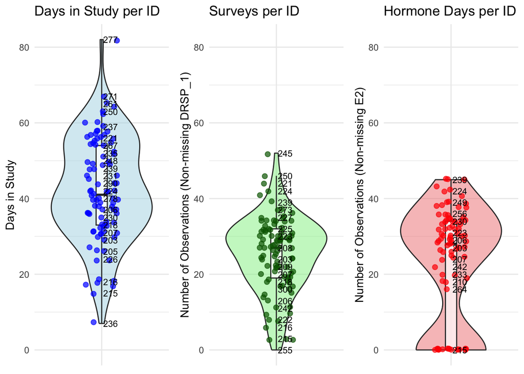

```r
# Count the total number of "Days in Study" (total observations per ID)
df_count <- df %>%
  group_by(id) %>%
  summarize(days_in_study = n())

# Count the number of non-missing observations per ID for the variable DRSP_1
df_nonmissing_count <- df %>%
  group_by(id) %>%
  summarize(number_of_observations = sum(!is.na(DRSP_1)))

# Count the number of non-missing observations for the variable E2
df_e2_nonmissing_count <- df %>%
  group_by(id) %>%
  summarize(e2_nonmissing = sum(!is.na(E2)))

#### Handle Outliers ONLY for "Days in Study" ####

# Outlier removal for "Days in Study"
Q1 <- quantile(df_count$days_in_study, 0.25)
Q3 <- quantile(df_count$days_in_study, 0.75)
IQR <- Q3 - Q1
lower_bound <- Q1 - 1.5 * IQR
upper_bound <- Q3 + 1.5 * IQR
df_no_outliers <- df_count %>%
  filter(days_in_study >= lower_bound & days_in_study <= upper_bound)

#### Determine Y-Axis Limits ####
y_min <- min(df_no_outliers$days_in_study, df_nonmissing_count$number_of_observations, df_e2_nonmissing_count$e2_nonmissing, na.rm = TRUE)
y_max <- max(df_no_outliers$days_in_study, df_nonmissing_count$number_of_observations, df_e2_nonmissing_count$e2_nonmissing, na.rm = TRUE)

#### Plots ####

# Plot "Days in Study" per ID (with outliers removed)
plot1_no_outliers <- ggplot(df_no_outliers, aes(x = factor(1), y = days_in_study, label = id)) +
  geom_violin(fill = "lightblue", alpha = 0.5) +  # Violin plot to show distribution
  geom_boxplot(width = 0.1, outlier.shape = NA, alpha = 0.7) +  # Boxplot inside the violin
  geom_jitter(width = 0.15, size = 2, color = "blue", alpha = 0.7) +  # Dots for raw data
  geom_text(aes(label = id), hjust = -0.1, size = 3, check_overlap = TRUE) +  # Add ID labels
  labs(x = NULL, y = "Days in Study", title = "Days in Study per ID") +
  theme_minimal() +
  theme(axis.text.x = element_blank(), axis.ticks.x = element_blank()) +
  ylim(y_min, y_max)

# Plot "Number of Observations" for DRSP_1 (without removing outliers)
plot2_no_outliers <- ggplot(df_nonmissing_count, aes(x = factor(1), y = number_of_observations, label = id)) +
  geom_violin(fill = "lightgreen", alpha = 0.5) +  # Violin plot to show distribution
  geom_boxplot(width = 0.1, outlier.shape = NA, alpha = 0.7) +  # Boxplot inside the violin
  geom_jitter(width = 0.15, size = 2, color = "darkgreen", alpha = 0.7) +  # Dots for raw data
  geom_text(aes(label = id), hjust = -0.1, size = 3, check_overlap = TRUE) +  # Add ID labels
  labs(x = NULL, y = "Number of Observations (Non-missing DRSP_1)", title = "Surveys per ID") +
  theme_minimal() +
  theme(axis.text.x = element_blank(), axis.ticks.x = element_blank()) +
  ylim(y_min, y_max)

# Plot "Number of non-missing E2 observations" (without removing outliers)
plot3_no_outliers <- ggplot(df_e2_nonmissing_count, aes(x = factor(1), y = e2_nonmissing, label = id)) +
  geom_violin(fill = "lightcoral", alpha = 0.5) +  # Violin plot to show distribution
  geom_boxplot(width = 0.1, outlier.shape = NA, alpha = 0.7) +  # Boxplot inside the violin
  geom_jitter(width = 0.15, size = 2, color = "red", alpha = 0.7) +  # Dots for raw data
  geom_text(aes(label = id), hjust = -0.1, size = 3, check_overlap = TRUE) +  # Add ID labels
  labs(x = NULL, y = "Number of Observations (Non-missing E2)", title = "Hormone Days per ID") +
  theme_minimal() +
  theme(axis.text.x = element_blank(), axis.ticks.x = element_blank()) +
  ylim(y_min, y_max)

# Combine the three plots on one page using grid.arrange from gridExtra
observations_plot <- grid.arrange(plot1_no_outliers, plot2_no_outliers, plot3_no_outliers, ncol = 3)
```

```r
# Save the combined plot to a file with the current date
ggsave(filename = paste0(output_folder, "N_observations_plot_", current_date, ".png"),
       plot = observations_plot,
       width = 8,
       height = 6)
```

# 41 —- Print Variable Names —-

```r
print.variable.names(df)
```

```
## -------- Names of variables in the raw dataset --------    id, daterated, TubeNumber, E2, P4, LH, StartPeriod, PosLHTest, HormoneVerified, VisitNumbers, daterated_dontuse, RecordedDate, CurrentTime, TodaysDate, recorded_time, recorded_date, hour_recorded, midnight_to_five, DEBQ_avg, BDEFS_1, BDEF…
```

~~~~~~~~~~~~~~~~~~~~~~~~~~~~~~~~~~~~~~~~~~~~~~~~~~~~~~~~~~~~

##### 41.0.0.0.1 END OF DATA PREP

# 42 Save out Prepped Dataset for Easier Use Later On

```r
write.csv(df, "/Users/taem-macbook-air/Library/CloudStorage/Box-Box/00 - CLEAR Lab (Locked Folders)/02 - Data Management, Analysis, and Papers/Studies_Projects/CYCLEADHD/03_analytic_projects/CYCADHD_PRIMARY/03_code_dataedits_output/adhd_daily_df_20241020.csv", row.names = FALSE)
```